# Problem Set 2

Author

Alexis Weaver

Published

October 15, 2026

**GitHub repo** https://github.com/Alexiswea/ec422_ps2_Weaver.git —

```r
library(tidyquant)
library(tidyverse)
library(knitr)
unemp_raw = read_rds("data/unemp_raw.rds")

#| label: wrangle
unemp <- unemp_raw |>
  rename(unemployment_rate = price) |>
  mutate(
    region = case_when(
      symbol == "UNRATE" ~ "United States",
      symbol == "ORUR"   ~ "Oregon",
      symbol == "CAUR"   ~ "California",
      symbol == "TXUR"   ~ "Texas",
      symbol == "NYUR"   ~ "New York",
      TRUE ~ NA_character_
    )
  )

#Replace the missing Oct 2025 value with the Sept 2025 value
unemp <- unemp |>
  arrange(region, date) |>
  group_by(region) |>
  mutate(
    unemployment_rate = replace(
      unemployment_rate,
      date == as.Date("2025-10-01"),
      unemployment_rate[date == as.Date("2025-09-01")]
    )
  ) |>
  ungroup()

# month-over-month change, computed within each region
unemp <- unemp |>
  arrange(region, date) |>
  group_by(region) |>
  mutate(unemployment_rate_change = unemployment_rate - lag(unemployment_rate)) |>
  ungroup()

unemp_recent <- unemp |>
  filter(date >= as.Date("2015-01-01"))

unemp_summary <- unemp |>
  group_by(region) |>
  summarize(
    mean_rate = mean(unemployment_rate, na.rm = TRUE),
    min_rate  = min(unemployment_rate,  na.rm = TRUE),
    max_rate  = max(unemployment_rate,  na.rm = TRUE)
  )

unemp_recent_summary <- unemp_recent |>
  group_by(region) |>
  summarize(
    mean_rate = mean(unemployment_rate, na.rm = TRUE),
    min_rate  = min(unemployment_rate,  na.rm = TRUE),
    max_rate  = max(unemployment_rate,  na.rm = TRUE)
  )

# largest monthly changes, excluding 2020
unemp_no_covid <- unemp |>
  filter(year(date) != 2020)

unemp_top_increases_no_covid <- unemp_no_covid |>
  slice_max(unemployment_rate_change, n = 5)

unemp_top_decreases_no_covid <- unemp_no_covid |>
  slice_min(unemployment_rate_change, n = 5)
```

DATA: The data are monthly, seasonally adjusted unemployment rates for the United States and four states (Oregon, California, Texas, and New York). They come from FRED, the Federal Reserve Economic Data database maintained by the Federal Reserve Bank of St. Louis, and were downloaded in R with the `tidyquant` package’s `tq_get()` function. The FRED series codes are `UNRATE` (U.S.), `ORUR` (Oregon), `CAUR` (California), `TXUR` (Texas), and `NYUR` (New York). Each series is observed monthly from January 1976 through September 2026. The data are in long format, with one row per series per month: `symbol` is the series code, `date` is the month, and `price` is the unemployment rate (in percent).

WRANGLING:

### Summary statistics, full sample

This table shows the mean, minimum, and maximum unemployment rate (in percent) for each region over the full sample, January 1976 to September 2026. Over this period, California had the highest average unemployment rate and Texas had the lowest.

```r
unemp_summary |>
  kable(
    digits = 2,
    col.names = c("Region", "Mean rate (%)", "Min rate (%)", "Max rate (%)"),
    caption = "Unemployment rate summary statistics by region, full sample"
  )
```

Unemployment rate summary statistics by region, full sample

| Region | Mean rate (%) | Min rate (%) | Max rate (%) |
| --- | --- | --- | --- |
| California | 7.07 | 3.8 | 16.1 |
| New York | 6.35 | 3.8 | 16.7 |
| Oregon | 6.66 | 3.4 | 13.7 |
| Texas | 5.85 | 3.4 | 12.8 |
| United States | 6.05 | 3.4 | 14.8 |

### Summary statistics, January 2015 onward

This table repeats the same statistics using only observations from January 2015 onward. Over this shorter window, California had the highest average unemployment rate and Texas had the lowest.

```r
unemp_recent_summary |>
  kable(
    digits = 2,
    col.names = c("Region", "Mean rate (%)", "Min rate (%)", "Max rate (%)"),
    caption = "Unemployment rate summary statistics by region, January 2015 onward"
  )
```

Unemployment rate summary statistics by region, January 2015 onward

| Region | Mean rate (%) | Min rate (%) | Max rate (%) |
| --- | --- | --- | --- |
| California | 5.63 | 3.8 | 16.1 |
| New York | 5.10 | 3.8 | 16.7 |
| Oregon | 4.75 | 3.4 | 13.7 |
| Texas | 4.58 | 3.4 | 12.8 |
| United States | 4.62 | 3.4 | 14.8 |

### Largest monthly increases, excluding 2020

This table shows the region-months with the largest one-month increases in the unemployment rate (in percentage points), after dropping all observations from 2020 so that the extreme COVID-19 movements do not dominate. Ties are included, so the table can have more than five rows.

```r
unemp_top_increases_no_covid |>
  select(region, date, unemployment_rate, unemployment_rate_change) |>
  kable(
    digits = 2,
    col.names = c("Region", "Month", "Unemployment rate (%)", "Change from prior month (pp)"),
    caption = "Largest month-over-month increases in the unemployment rate, excluding 2020"
  )
```

Largest month-over-month increases in the unemployment rate, excluding 2020

| Region | Month | Unemployment rate (%) | Change from prior month (pp) |
| --- | --- | --- | --- |
| Texas | 2009-05-01 | 7.6 | 1.1 |
| Oregon | 2008-12-01 | 8.9 | 0.7 |
| Oregon | 2008-11-01 | 8.2 | 0.7 |
| Oregon | 2009-01-01 | 9.6 | 0.7 |
| Oregon | 1980-03-01 | 7.4 | 0.6 |
| United States | 1980-04-01 | 6.9 | 0.6 |

### Largest monthly decreases, excluding 2020

This table shows the region-months with the largest one-month decreases in the unemployment rate (in percentage points), again excluding 2020. Ties are included.

```r
unemp_top_decreases_no_covid |>
  select(region, date, unemployment_rate, unemployment_rate_change) |>
  kable(
    digits = 2,
    col.names = c("Region", "Month", "Unemployment rate (%)", "Change from prior month (pp)"),
    caption = "Largest month-over-month decreases in the unemployment rate, excluding 2020"
  )
```

Largest month-over-month decreases in the unemployment rate, excluding 2020

| Region | Month | Unemployment rate (%) | Change from prior month (pp) |
| --- | --- | --- | --- |
| United States | 1983-07-01 | 9.4 | -0.7 |
| New York | 2021-09-01 | 6.2 | -0.6 |
| Oregon | 1977-05-01 | 7.8 | -0.5 |
| California | 2021-07-01 | 7.4 | -0.5 |
| California | 2021-09-01 | 6.5 | -0.5 |
| New York | 2021-07-01 | 7.0 | -0.5 |
| United States | 2010-12-01 | 9.3 | -0.5 |
| United States | 2014-04-01 | 6.2 | -0.5 |
| United States | 2021-07-01 | 5.4 | -0.5 |

VISUALIZATION:

### Unemployment rates for all regions

This figure plots the monthly unemployment rate for the United States and the four states on a single set of axes, with one colored line per region. It makes it easy to compare levels across regions and to see how the series move together, including the sharp spikes during recessions.

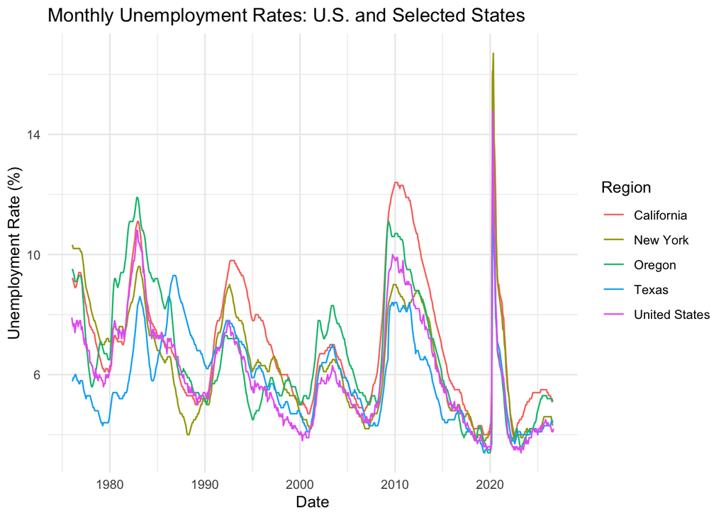

```r
ggplot(unemp, aes(x = date, y = unemployment_rate, color = region)) +
  geom_line() +
  labs(
    title = "Monthly Unemployment Rates: U.S. and Selected States",
    x = "Date",
    y = "Unemployment Rate (%)",
    color = "Region"
  ) +
  theme_minimal()
```

### Unemployment rates by region (separate panels)

This figure shows the same data as the previous plot, but with a separate panel for each region. This avoids the overlapping lines and makes each region’s own history easier to read.

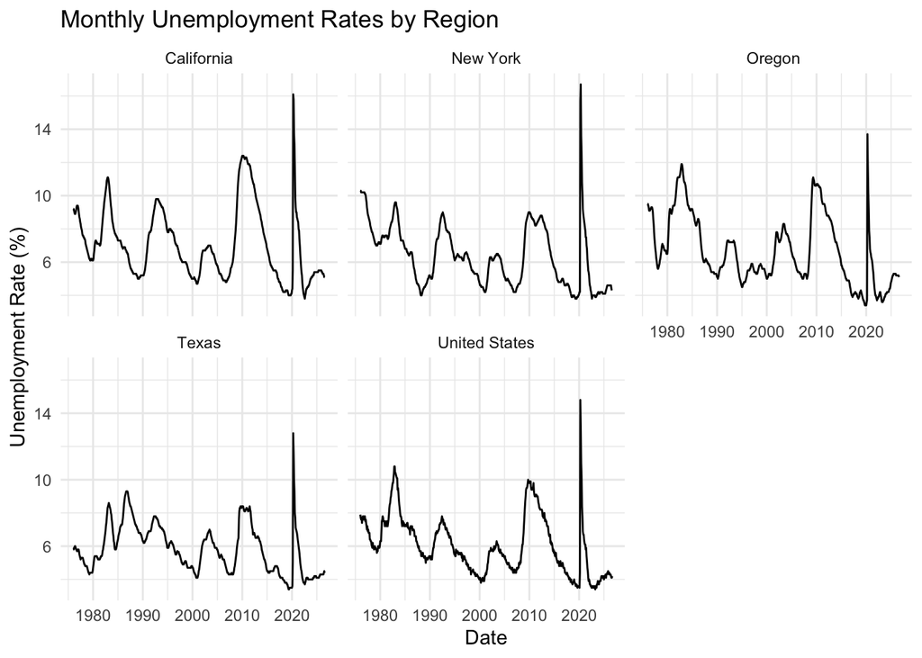

```r
ggplot(unemp, aes(x = date, y = unemployment_rate)) +
  geom_line() +
  facet_wrap(~ region) +
  labs(
    title = "Monthly Unemployment Rates by Region",
    x = "Date",
    y = "Unemployment Rate (%)"
  ) +
  theme_minimal()
```

### Average unemployment rate by region

This bar chart shows the mean unemployment rate over the full sample for each region, ordered from lowest to highest.

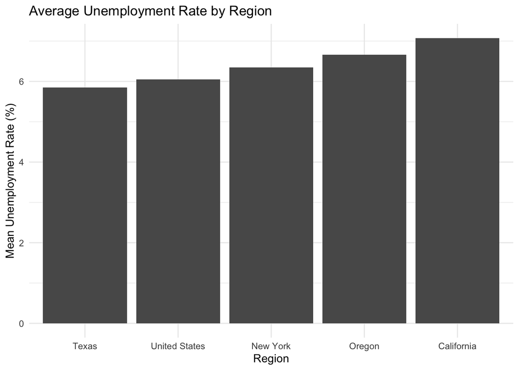

```r
ggplot(unemp_summary, aes(x = fct_reorder(region, mean_rate), y = mean_rate)) +
  geom_col() +
  labs(
    title = "Average Unemployment Rate by Region",
    x = "Region",
    y = "Mean Unemployment Rate (%)"
  ) +
  theme_minimal()
```

### Oregon relative to the United States

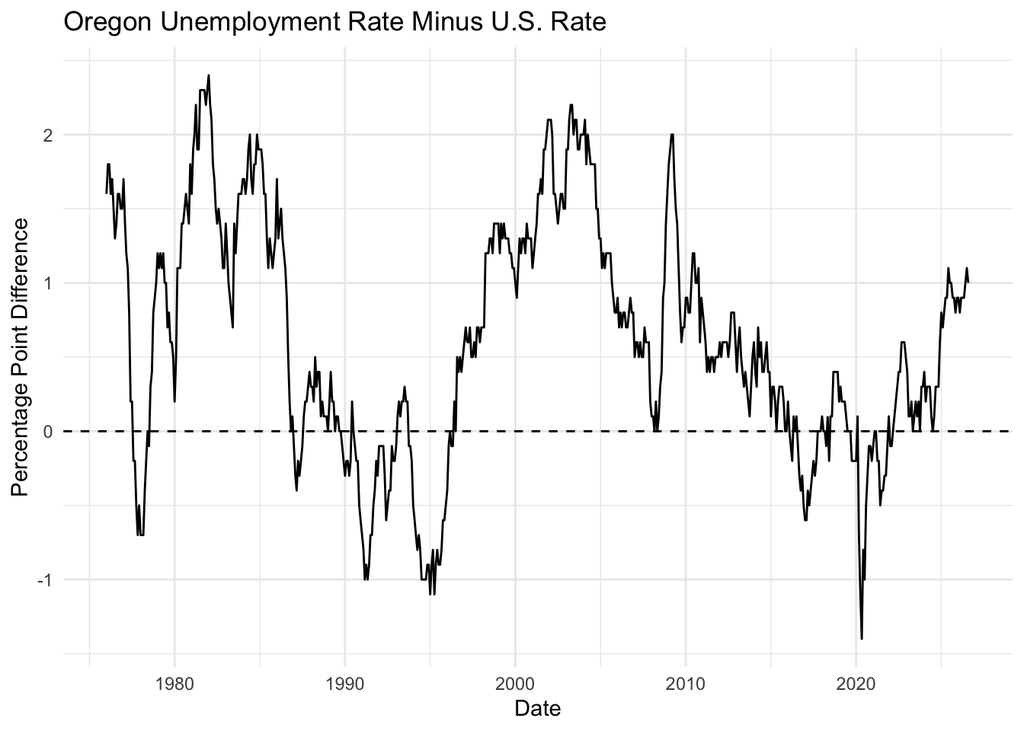

```r
oregon_gap <- unemp |>
  filter(symbol %in% c("ORUR", "UNRATE")) |>
  dplyr::select(date, symbol, unemployment_rate) |>
  pivot_wider(names_from = symbol, values_from = unemployment_rate) |>
  mutate(gap = ORUR - UNRATE)

ggplot(oregon_gap, aes(x = date, y = gap)) +
  geom_line() +
  geom_hline(yintercept = 0, linetype = "dashed") +
  labs(
    title = "Oregon Unemployment Rate Minus U.S. Rate",
    x = "Date",
    y = "Percentage Point Difference"
  ) +
  theme_minimal()
```

REFLECTION:

The most straightforward part of this problem set was reading in the FRED data and using the dplyr verbs to filter, group, and summarize it, since the starter code made the structure clear. What tripped me up was an error when building the Oregon-versus-U.S. plot, where reshaping the data with `pivot_wider()` did not create the column I expected, and I had to track down the cause by checking the data directly. I also had to be careful to group by region before using `lag()` so that each region’s changes were computed separately. One thing I feel more comfortable with now is committing and pushing to GitHub in stages due to my experience in cs projects. Overall, seeing the whole workflow from raw data to a finished report in one place helped me understand how the pieces fit together.